# autothresholdr

Rory Nolan

2018-07-09

# Thresholding Images

This is a package for thresholding images. Let’s load it and some friends.

```r
library(autothresholdr)
library(ijtiff)
library(magrittr)
```

We’ll be using the image that comes with the package:

```r
img <- read_tif(system.file("extdata", "fiji_eg.tif",
                            package = "autothresholdr"))
```

```
#> Reading fiji_eg.tif: an 8-bit, 130x130 pixel image of unsigned integer type with 1 channel and 1 frame . . .
#>  Done.
```

```r
dim(img)
```

```
#> [1] 130 130   1   1
```

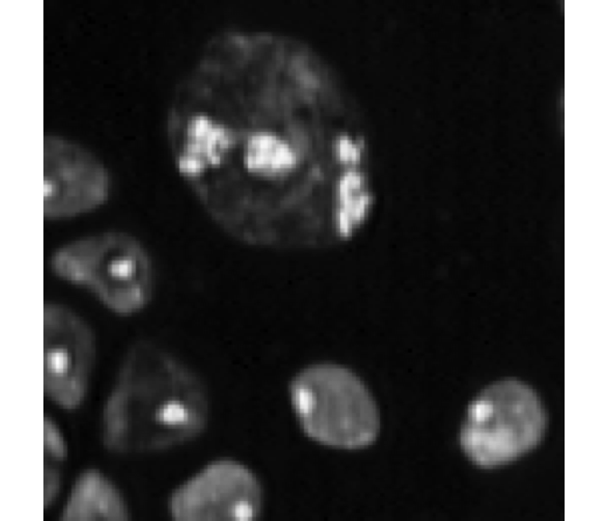

```r
display(img[, , 1, 1])  # first channel, first frame
```

It’s a bit of a cell, the black part is where the cell is not. The threshold is supposed to tell us what is *dark* (not cell) and what is *bright* (cell). By playing around, we see that something like 20 might (for some purposes) be a good value.

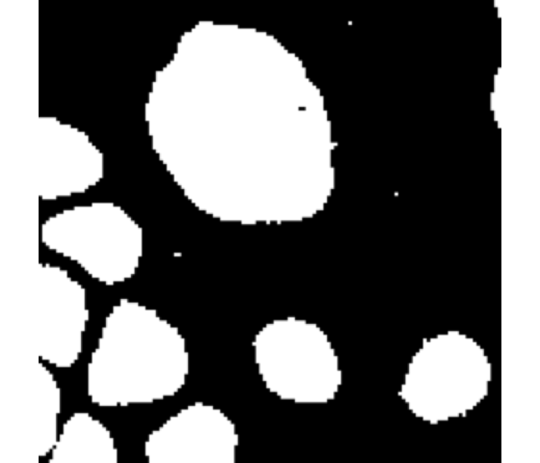

```r
display(img[, , 1, 1] > 20)
```

But what if we have many images and we don’t want to *play around*, we want a method of calculating the threshold automatically. http://imagej.net/Auto_Threshold gives many such methods and they are provided to you in R via this package. Go to that webpage for a nice comparison of the methods.

The function `auto_thresh()` finds the threshold, `auto_thresh_mask()` gets the mask (an array with a `TRUE` for elements exceeding the threshold and `FALSE` elsewhere) and `auto_thresh_apply_mask()` applies the mask to the original image by setting the elements that don’t exceed the threshold to `NA`.

Let’s see each with Huang thresholding.

```r
auto_thresh(img, "huang")
```

```
#> [1] 23
#> attr(,"ignore_black")
#> [1] FALSE
#> attr(,"ignore_white")
#> [1] FALSE
#> attr(,"ignore_na")
#> [1] FALSE
#> attr(,"autothresh_method")
#> [1] "Huang"
#> attr(,"class")
#> [1] "th"      "integer"
```

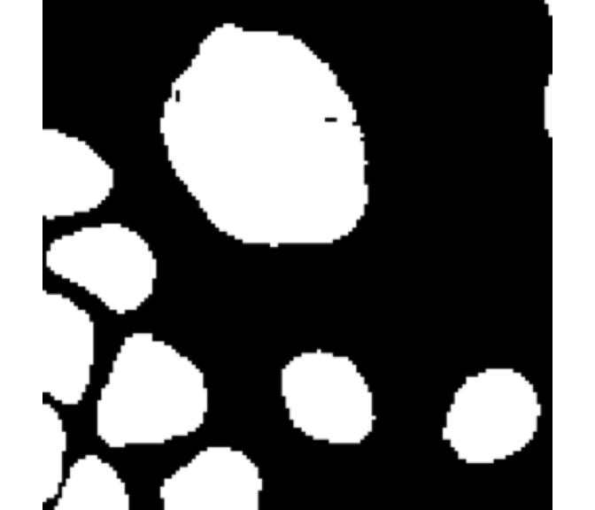

```r
auto_thresh_mask(img, "huang") %>% {display(.[, , 1, 1])}
```

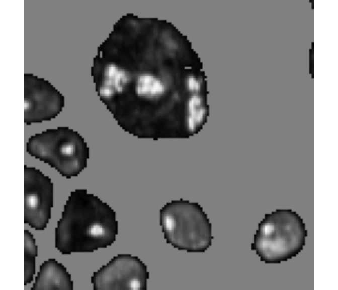

```r
auto_thresh_apply_mask(img, "huang") %>% {display(.[, , 1, 1])}
```

## Stacks of Images

We can do the same thing with an image stack.

```r
img <- read_tif(system.file("extdata", "50.tif",
                            package = "autothresholdr"))
```

```
#> Reading 50.tif: an 8-bit, 100x100 pixel image of unsigned integer type with 1 channel and 50 frames . . .
#>  Done.
```

```r
dim(img)
```

```
#> [1] 100 100   1  50
```

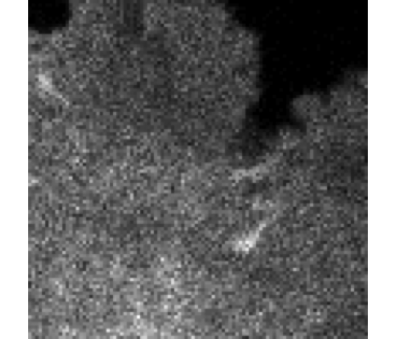

```r
display(img[, , 1, 1])
```

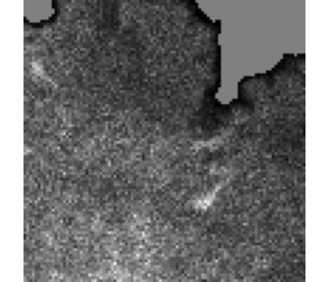

```r
mean_stack_thresh(img, "tri") %>% {display(.[, , 1, 1])}
```

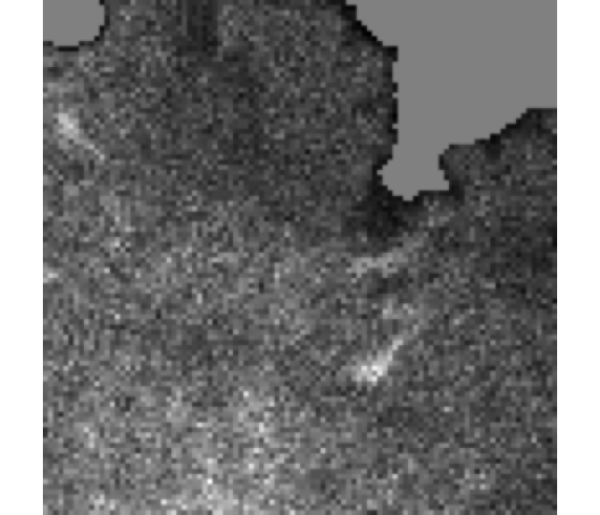

```r
med_stack_thresh(img, "tri") %>% {display(.[, , 1, 1])}
```

These are indeed (on close inspection) slightly different.